# R Notebook

**Principles of Data Visualization and Introduction to ggplot2**

I have provided you with data about the 5,000 fastest growing companies in the US, as compiled by Inc. magazine. lets read this in:

```r
inc <- read.csv("https://raw.githubusercontent.com/charleyferrari/CUNY_DATA_608/master/module1/Data/inc5000_data.csv", header = TRUE)
```

And lets preview this data:

```r
head(inc)
```

|  | Rank | Name | Growth_Rate | Revenue | Industry | Employees | City | State |
| --- | --- | --- | --- | --- | --- | --- | --- | --- |
| 1 | 1 | Fuhu | 421.48 | 1.179e+08 | Consumer Products & Services | 104 | El Segundo | CA |
| 2 | 2 | FederalConference.com | 248.31 | 4.960e+07 | Government Services | 51 | Dumfries | VA |
| 3 | 3 | The HCI Group | 245.45 | 2.550e+07 | Health | 132 | Jacksonville | FL |
| 4 | 4 | Bridger | 233.08 | 1.900e+09 | Energy | 50 | Addison | TX |
| 5 | 5 | DataXu | 213.37 | 8.700e+07 | Advertising & Marketing | 220 | Boston | MA |
| 6 | 6 | MileStone Community Builders | 179.38 | 4.570e+07 | Real Estate | 63 | Austin | TX |

```r
summary(inc)
```

```
      Rank          Name            Growth_Rate
 Min.   :   1   Length:5001        Min.   :  0.340
 1st Qu.:1252   Class :character   1st Qu.:  0.770
 Median :2502   Mode  :character   Median :  1.420
 Mean   :2502                      Mean   :  4.612
 3rd Qu.:3751                      3rd Qu.:  3.290
 Max.   :5000                      Max.   :421.480

    Revenue            Industry           Employees
 Min.   :2.000e+06   Length:5001        Min.   :    1.0
 1st Qu.:5.100e+06   Class :character   1st Qu.:   25.0
 Median :1.090e+07   Mode  :character   Median :   53.0
 Mean   :4.822e+07                      Mean   :  232.7
 3rd Qu.:2.860e+07                      3rd Qu.:  132.0
 Max.   :1.010e+10                      Max.   :66803.0
                                        NA's   :12
     City              State
 Length:5001        Length:5001
 Class :character   Class :character
 Mode  :character   Mode  :character
```

Think a bit on what these summaries mean. Use the space below to add some more relevant non-visual exploratory information you think helps you understand this data:

Some additional interesting information we can get from this data set is the number of unique values in certain columns.

For example, the number of unique values in the “Industry” column is:

```r
nrow(unique(inc["Industry"]))
```

```
[1] 25
```

And the number of unique values in the “State” column is:

```r
nrow(unique(inc["State"]))
```

```
[1] 52
```

Interestingly there are 52 unique values for the State column which tells us that most likely every state is being respresented and that there are two additional values that likely represent Washington DC and Puerto Rico.

Another interesting stat we can get from this data non-visually is checking the number of NA values in each column. This can be done by using the `colSums(is.na(inc))` function.

```r
colSums(is.na(inc))
```

```
       Rank        Name Growth_Rate     Revenue    Industry
          0           0           0           0           0
  Employees        City       State
         12           0           0
```

Here we see that only the “Employees” column has NA values. This tells us we likely will not need to do much data cleaning for this data set.

## Question 1

Create a graph that shows the distribution of companies in the dataset by State (ie how many are in each state). There are a lot of States, so consider which axis you should use. This visualization is ultimately going to be consumed on a ‘portrait’ oriented screen (ie taller than wide), which should further guide your layout choices.

[figure not shown]

```r
# Answer Question 1 here
library(dplyr)
library(ggplot2)

# Answer Question 1 here
inc %>%
  count(State, n(), sort = T) %>%
  ggplot(aes(x = reorder(State, n), y = n)) +
  geom_col() +
  coord_flip() +
  labs(x = "State", y = "Number of Companies")
```

## Quesiton 2

Lets dig in on the state with the 3rd most companies in the data set. Imagine you work for the state and are interested in how many people are employed by companies in different industries. Create a plot that shows the average and/or median employment by industry for companies in this state (only use cases with full data, use R’s `complete.cases()` function.) In addition to this, your graph should show how variable the ranges are, and you should deal with outliers.

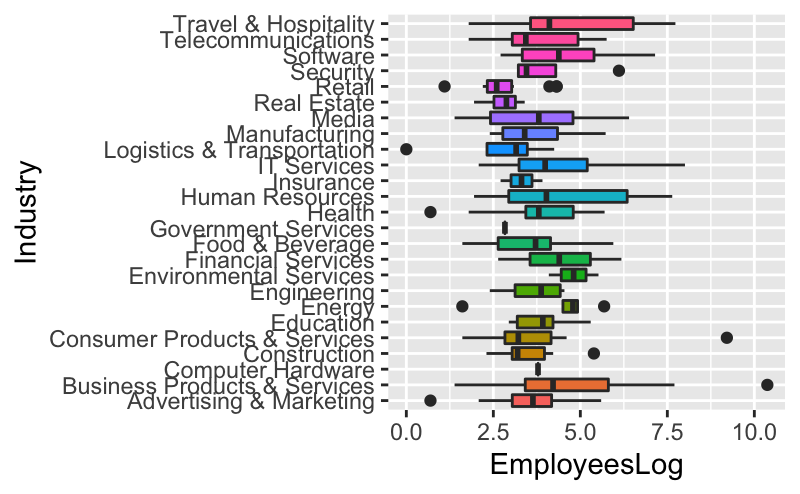

```r
incNy <- inc %>% filter(complete.cases(.) & State == 'NY')
incNy$EmployeesLog <- log(incNy$Employees)
# plot a violin plot
ggplot(incNy, aes(x = EmployeesLog, y = Industry, fill = Industry)) +
  geom_boxplot() +
  theme(legend.position = "none")
```

## Question 3

Now imagine you work for an investor and want to see which industries generate the most revenue per employee. Create a chart that makes this information clear. Once again, the distribution per industry should be shown.

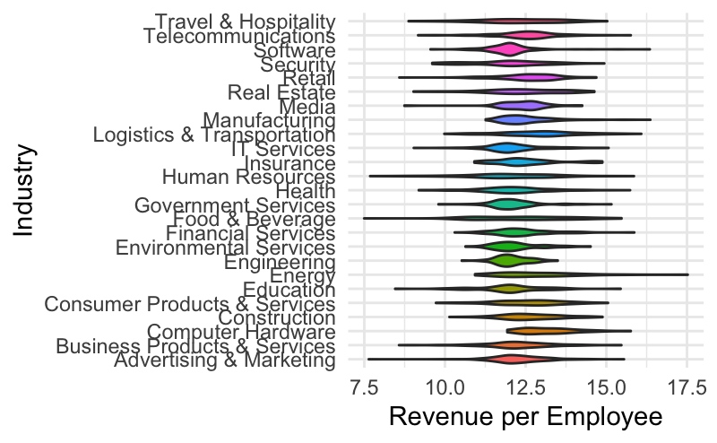

```r
# Answer Question 3 here
ggplot(inc, aes(x = Industry, y = log(Revenue / Employees), fill = Industry)) +
  geom_violin() +
  scale_y_continuous(name = "Revenue per Employee") +
  theme_minimal() +
  coord_flip() +
  theme(legend.position = "none")
```